# ProjectFG

Flavio Agostini, Vladimir Vranjes

2023-03-31

# Introduction: Aim and Experimental Design

**Aim:** The aim of this study is to investigate the role of IL-17A in the pathogenesis of systemic sclerosis (SSc), a connective tissue disorder characterized by fibrosis and inflammation. The data will help directing and interpreting therapeutic approaches in SSc, since both, IL-17A and TGF-β, are target candidates in clinical trials.

**Experimental Design:** To evaluate the potential role of IL-17A in the context of fibrosis and to overcome the limitations associated with two-dimensional cultures, a model of fibrosis was enstablished based on repeated injections of TGF-β into normal full human skin cultured in semi-solid agar. Under these culture conditions for up to 9 days, the skin maintained normal morphology with very few apoptotic cells. To extensively evaluate the gene expression profile in this organotypic model after treatment with TGF-β, we performed RNA sequencing. A similar process has been applied with injections of IL-17A and of combined IL-17A and TGF-β.

For the RNA-seq procedure, RNA was isolated from three independent skin donors with mirVana miRNA Isolation Kit from Invitrogen Integrity and quantity of RNA were assessed with Bioanalyzer cDNA libraries were constructed using Illumina TruSeq RNA stranded Kit. Pools of 18 libraries were loaded at 2 nM for clustering on two lanes of a Single-read Illumina Flow cell. Reads of 50 bases were generated using the TruSeq SBS chemistry on an Illumina HiSeq 4000 sequencer. FastQ reads were mapped to the ENSEMBL reference genome (GRCh38.89) using STAR, version 2.4.0j.

**Statistical analysis:** In the article, library size normalizations and differential gene expression calculations were performed using the package edgeR (Robinson et al., 2010) designed for the R software (Team, 2011). Only genes having a significant fold-change (Benjamini-Hochberg corrected P-value <0.001) were considered for the rest of the RNA sequencing analysis.

## Data import and exploratory data analysis

```r
GEOid="GSE122305"
gse = GEOquery::getGEO(GEOid,destdir=getwd())[[1]]
```

```
## Found 1 file(s)
```

```
## GSE122305_series_matrix.txt.gz
```

```
## Using locally cached version: D:/libri uni/terzo anno/FunctionalGenomics/FGproject/GSE122305_series_matrix.txt.gz
```

```
## Using locally cached version of GPL20301 found here:
## D:/libri uni/terzo anno/FunctionalGenomics/FGproject/GPL20301.soft.gz
```

```r
se = as(gse, "SummarizedExperiment")
se
```

```
## class: SummarizedExperiment
## dim: 0 18
## metadata(3): experimentData annotation protocolData
## assays(1): exprs
## rownames(0):
## rowData names(0):
## colnames(18): GSM3463717 GSM3463718 ... GSM3463733 GSM3463734
## colData names(38): title geo_accession ... tissue.ch1 treatment.ch1
```

```r
assays(se)$exprs%>%head
```

```
##      GSM3463717 GSM3463718 GSM3463719 GSM3463720 GSM3463721 GSM3463722
##      GSM3463723 GSM3463724 GSM3463725 GSM3463726 GSM3463727 GSM3463728
##      GSM3463729 GSM3463730 GSM3463731 GSM3463732 GSM3463733 GSM3463734
```

```r
#head(colData(se))
#head(metadata(se))
```

We import the rds file and we do some basic filtering.

```r
ddslist<-readRDS(file = "dds.rds")
dds<-ddslist$source_name_ch1
keep <- rowSums(counts(dds)) > 1
dds <- dds[keep,]
nrow(dds)
```

```
## [1] 17604
```

Before plotting, we need to apply data transformation. Here we plot the results of the two methods offered by DeSeq2: vst and rlog. In this plot we see the effect of the transformation in action: in the first plot we can notice that lower count genes appear to be scattered. After the transformation (vst or rlog) the counts appear to be “squished” around the mean.

```r
vsd <- vst(dds, blind = FALSE)

rld <- rlog(dds, blind = FALSE)

dds2 <- estimateSizeFactors(dds)

df <- bind_rows(
  as_data_frame(log2(counts(dds2, normalized=TRUE)[, 1:2]+1)) %>%
    mutate(transformation = "log2(x + 1)"),
  as_data_frame(assay(vsd)[, 1:2]) %>% mutate(transformation = "vst"),
  as_data_frame(assay(rld)[, 1:2]) %>% mutate(transformation = "rlog"))
```

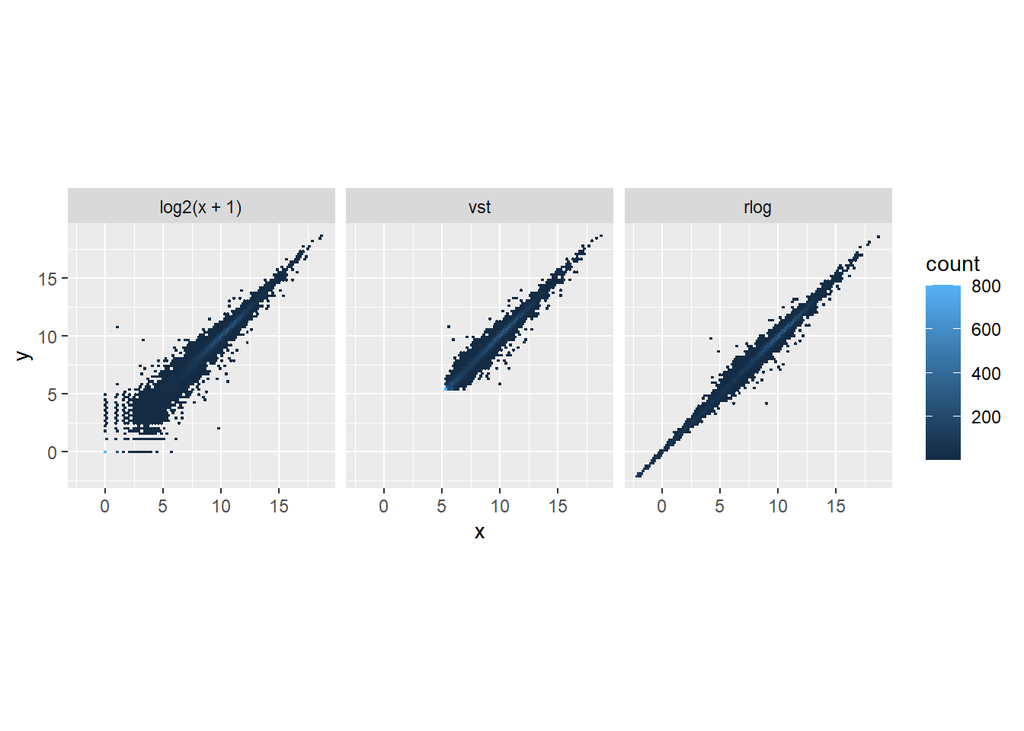

```r
colnames(df)[1:2] <- c("x", "y")

lvls <- c("log2(x + 1)", "vst", "rlog")
df$transformation <- factor(df$transformation, levels=lvls)

ggplot(df, aes(x = x, y = y)) + geom_hex(bins = 80) +
  coord_fixed() + facet_grid( . ~ transformation)
```

We can now compute the distances beetween samples and create a Heatmap. From the heatmap we can see that the samples have been clustered similarly as we expected. We note a sample (TNF treated) that’s not clustered with the others TNF samples. We will assess this better in the PCA plot.

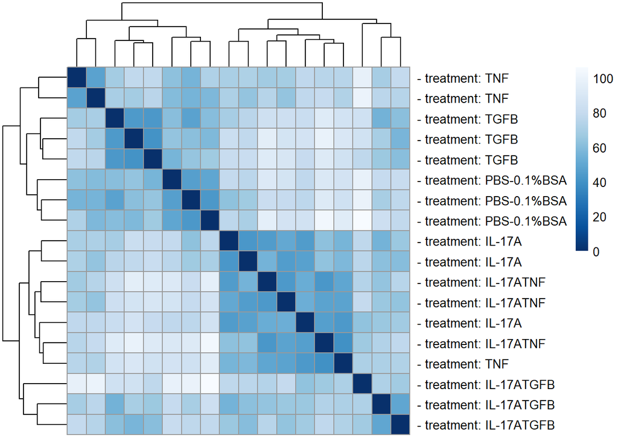

```r
#--HEATMAP--#
sampleDists <- dist(t(assay(vsd)))
sampleDistMatrix <- as.matrix( sampleDists )
rownames(sampleDistMatrix) <-  paste( vsd$genotype.ch1,vsd$characteristics_ch1.1, sep = " - " )
#rownames(sampleDistMatrix) <- vsd$title
colnames(sampleDistMatrix) <- NULL
colors <- colorRampPalette( rev(brewer.pal(9, "Blues")) )(255)
pheatmap(sampleDistMatrix,
         clustering_distance_rows = sampleDists,
         clustering_distance_cols = sampleDists,
         col = colors)
```

With a PCA plot we confirm that the samples present a good clustering tendency, with the exception of a TNF sample. This result may be due to human error in sequencing procedure, or from biological variation.

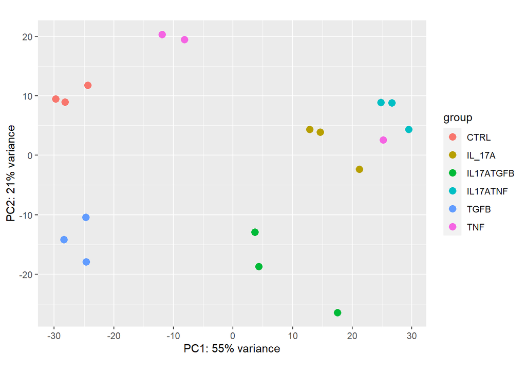

```r
#---PCA----

vsd <- vst(dds, blind = FALSE)
plotPCA(vsd, intgroup = c("source_name_ch1"))
```

We present the data in another way, based on sample distances: MDS Plot. The information is similar to PCA plot.

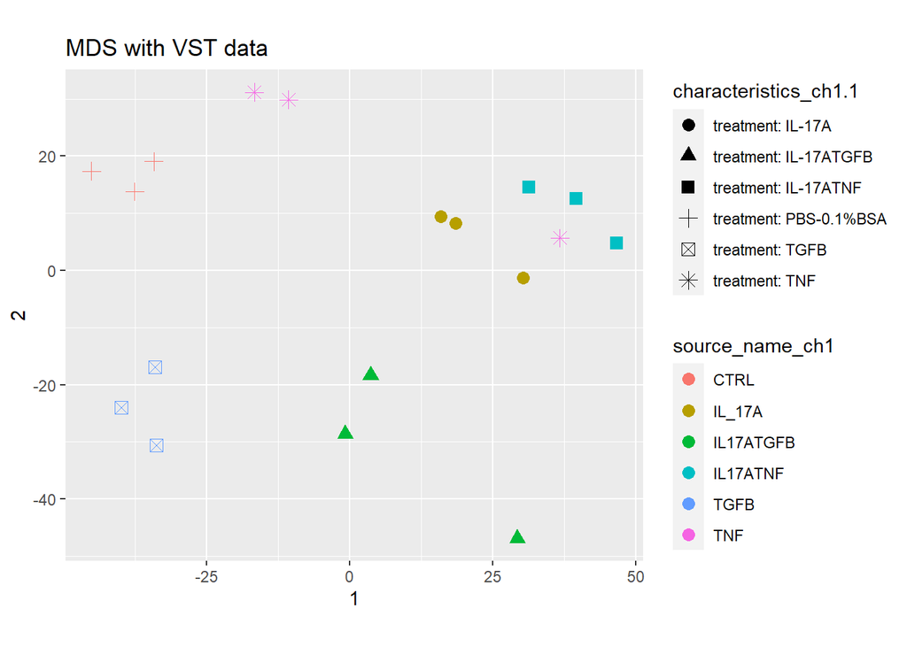

```r
#--MDS--#
mds <- as.data.frame(colData(vsd))  %>%
  cbind(cmdscale(sampleDistMatrix))


ggplot(mds, aes(x = `1`, y = `2`, color = source_name_ch1, shape = characteristics_ch1.1)) +
  geom_point(size = 3) + coord_fixed() + ggtitle("MDS with VST data")
```

# Differential expression analysis:

At first, we compare IL_17A treated with control group.

```r
dds <- DESeq(dds)
res <- results(dds, contrast=c("source_name_ch1","IL_17A","CTRL"))
mcols(res, use.names = TRUE) %>% as_tibble()
```

```
## # A tibble: 6 × 2
##   type         description
##   <chr>        <chr>
## 1 intermediate mean of normalized counts for all samples
## 2 results      log2 fold change (MLE): source_name_ch1 IL_17A vs CTRL
## 3 results      standard error: source name ch1 IL 17A vs CTRL
## 4 results      Wald statistic: source name ch1 IL 17A vs CTRL
## 5 results      Wald test p-value: source name ch1 IL 17A vs CTRL
## 6 results      BH adjusted p-values
```

```r
summary(res)
```

```
##
## out of 17604 with nonzero total read count
## adjusted p-value < 0.1
## LFC > 0 (up)       : 1434, 8.1%
## LFC < 0 (down)     : 1726, 9.8%
## outliers [1]       : 15, 0.085%
## low counts [2]     : 1707, 9.7%
## (mean count < 3)
## [1] see 'cooksCutoff' argument of ?results
## [2] see 'independentFiltering' argument of ?results
```

**Multiple testing:**

We ask: how many genes are differentially expressed based on p-value? We used 0.001 threshold, based on the paper indications.

```r
sum(res$pvalue < 0.001, na.rm=TRUE)
```

```
## [1] 1316
```

```r
sum(!is.na(res$pvalue))
```

```
## [1] 17589
```

```r
sum(res$padj < 0.001, na.rm=TRUE)
```

```
## [1] 581
```

We subset the results table to these genes and then sort it by the log2 fold change estimate to get the significant genes with the strongest down-regulation and strongest up-regulation. We are also interested in genes with lowest padj and in the count of up regulated and downregulated genes. We use padj instead of p-value. In this way we avoid including too many false positives in our DE genes (benjamini-Hochberg FDR).

```r
resSig <- subset(res, padj < 0.001)
head(resSig[ order(resSig$log2FoldChange), ])
```

```
## log2 fold change (MLE): source_name_ch1 IL_17A vs CTRL
## Wald test p-value: source name ch1 IL 17A vs CTRL
## DataFrame with 6 rows and 6 columns
##                   baseMean log2FoldChange     lfcSE      stat      pvalue
##                  <numeric>      <numeric> <numeric> <numeric>   <numeric>
## ENSG00000162747    86.7695      -10.24231  1.918738  -5.33804 9.39553e-08
## ENSG00000197353   310.0592       -9.67472  1.538938  -6.28662 3.24449e-10
## ENSG00000172867 11652.2550       -9.56477  1.420966  -6.73117 1.68300e-11
## ENSG00000143520 36749.4111       -9.44205  1.145609  -8.24194 1.69437e-16
## ENSG00000125571   108.2809       -8.35832  1.110094  -7.52938 5.09825e-14
## ENSG00000203782  6411.5490       -8.21237  0.957481  -8.57705 9.73341e-18
##                        padj
##                   <numeric>
## ENSG00000162747 8.33630e-06
## ENSG00000197353 6.52265e-08
## ENSG00000172867 4.77311e-09
## ENSG00000143520 1.58294e-13
## ENSG00000125571 2.79208e-11
## ENSG00000203782 1.54698e-14
```

```r
head(resSig[ order(resSig$log2FoldChange, decreasing = TRUE), ])
```

```
## log2 fold change (MLE): source_name_ch1 IL_17A vs CTRL
## Wald test p-value: source name ch1 IL 17A vs CTRL
## DataFrame with 6 rows and 6 columns
##                   baseMean log2FoldChange     lfcSE      stat      pvalue
##                  <numeric>      <numeric> <numeric> <numeric>   <numeric>
## ENSG00000156282   213.2106        6.71950  0.783435   8.57697 9.74048e-18
## ENSG00000244094 10558.0486        6.51788  0.478862  13.61118 3.43631e-42
## ENSG00000136694   424.2141        6.29774  0.904357   6.96378 3.31272e-12
## ENSG00000104327    21.5387        5.79591  1.110434   5.21950 1.79410e-07
## ENSG00000171711   944.6987        4.74457  0.634468   7.47802 7.54525e-14
## ENSG00000142224   103.3268        4.38591  0.838289   5.23198 1.67707e-07
##                        padj
##                   <numeric>
## ENSG00000156282 1.54698e-14
## ENSG00000244094 5.45754e-38
## ENSG00000136694 1.05225e-09
## ENSG00000104327 1.42469e-05
## ENSG00000171711 3.83165e-11
## ENSG00000142224 1.35204e-05
```

```r
head(resSig[ order(resSig$padj), ])
```

```
## log2 fold change (MLE): source_name_ch1 IL_17A vs CTRL
## Wald test p-value: source name ch1 IL 17A vs CTRL
## DataFrame with 6 rows and 6 columns
##                   baseMean log2FoldChange     lfcSE      stat      pvalue
##                  <numeric>      <numeric> <numeric> <numeric>   <numeric>
## ENSG00000244094 10558.0486        6.51788  0.478862  13.61118 3.43631e-42
## ENSG00000134765  4084.8938       -8.05428  0.846117  -9.51912 1.74656e-21
## ENSG00000196407   411.5055       -3.84397  0.407913  -9.42350 4.36295e-21
## ENSG00000010030   186.8827       -2.62952  0.281021  -9.35701 8.20279e-21
## ENSG00000140519 12500.0551        3.55967  0.381637   9.32736 1.08543e-20
## ENSG00000161944    48.3642       -4.56343  0.516981  -8.82706 1.07460e-18
##                        padj
##                   <numeric>
## ENSG00000244094 5.45754e-38
## ENSG00000134765 1.38694e-17
## ENSG00000196407 2.30975e-17
## ENSG00000010030 3.25692e-17
## ENSG00000140519 3.44777e-17
## ENSG00000161944 2.84446e-15
```

```r
count(resSig$log2FoldChange > 0)
```

```
## [1] 202
```

```r
count(resSig$log2FoldChange < 0)
```

```
## [1] 379
```

Our top 5 genes based on lowest padj are :

ENSG00000244094 -> **SPRR2F small proline rich protein 2F [ Homo sapiens (human) ]**  
l2fc: 6.51788 - padj: 5.40634e-38

This protein is predicted to be involved in keratinization, also termed as cornification. This is a process of cytodifferentiation that the keratinocytes undergo when proceeding from their post germinative state (stratum basale) to finally differentiated. This process may be enhanched during inflammation to allow the replacement of damaged skin cells. (Shetty and Gokul 2012)

The protein can be related to autoinflammatory keratinization diseases. Inflammation caused by the hyper-activation of innate immunity due to genetic factors occasionally leads to inflammatory keratinization diseases of the skin. Such inflammatory keratinization diseases with genetic autoinflammatory pathomechanisms are called “autoinflammatory keratinization diseases” (AiKDs). (Akiyama 2020)

SPRR2 proteins have been shown to protect against reactive oxygen species (ROS) in keratinocytes. It is shown that Sprr2f acts to dampen damage due to ROS in renal injury, likely from postinjury inflammation. A Sprr2f-KO mice show greater degree of fibrosis formation after UUO (unilateral ureteral obstruction). This could indicate an antif-ibrosis function of this gene. (Huynh et al. 2020)

ENSG00000134765 -> **DSC1 desmocollin 1**  
l2fc: -8.05428 - padj: 1.37393e-17

The protein encoded by this gene is a calcium-dependent glycoprotein that is a member of the desmocollin subfamily of the cadherin superfamily. These desmosomal family members, along with the desmogleins, are found primarily in epithelial cells where they constitute the adhesive proteins of the desmosome cell-cell junction and are required for cell adhesion and desmosome formation.

It is shown that DSG1 inhibits skin inflammation by inhibiting the NF-κB signaling pathway. Various observations support that DSG1 deficiency is linked to inflammation. First, DSG1 deficiency has been reported in patients with atopic dermatitis and Netherton syndrome, which share chronic inflammatory dermatitis and allergic manifestations with SAMEC. Second, 2 siblings presented with Netherton syndrome and normal DSG1 epidermal staining, whereas no skin inflammation was observed. Third, DSG1 deficiency is probably responsible for the mucosal barrier impairment and inflammation observed in patients with eosinophilic esophagitis. (Polivka et al. 2018)

ENSG00000196407 -> **THEM5 thioesterase superfamily member 5**  
l2fc: -3.84397 - padj 2.28808e-17

Enables palmitoyl-CoA hydrolase activity. Involved in long-chain fatty-acyl-CoA metabolic process. The enzyme is up-regulated during times of increased fatty acid oxidation.

In this paper it is reported that fatty acid oxidation lowers inflammation in macrophages. We suggest that this gene is therefore downregulated during inflammation caused by IL-17A. (Namgaladze and Brüne 2016)

ENSG00000010030 -> **ETS variant transcription factor 7**  
l2fc: -2.62952 - padj: 3.22636e-17

The protein encoded by this gene belongs to the ETS family of transcription factors, which is a large group of evolutionarily conserved transcriptional regulators that play an important role in a variety of cellular processes throughout development and differentiation, and are involved in oncogenesis as well.

It is hypothesized that regulators, like ETV7, are important to prevent excessive inflammatory signaling. Again this gene is downregulated in treated cells. (Froggatt et al. 2021)

ENSG00000140519 -> **RHCG Rh family C glycoprotein**  
l2fc: 3.55967 - padj: 3.41542e-17

Enables ammonium transmembrane transporter activity; ankyrin binding activity; and identical protein binding activity. Involved in ammonium transmembrane transport; cellular ion homeostasis; and transepithelial ammonium transport.

MA plot:

```r
res <- lfcShrink(dds, coef="source_name_ch1_IL_17A_vs_CTRL", type="apeglm")
```

```
## using 'apeglm' for LFC shrinkage. If used in published research, please cite:
##     Zhu, A., Ibrahim, J.G., Love, M.I. (2018) Heavy-tailed prior distributions for
##     sequence count data: removing the noise and preserving large differences.
##     Bioinformatics. https://doi.org/10.1093/bioinformatics/bty895
```

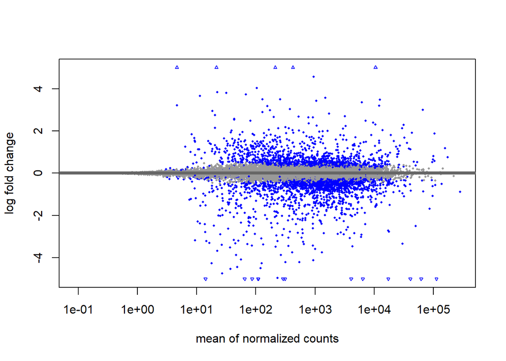

```r
DESeq2::plotMA(res, ylim = c(-5, 5))
```

We now plot the top genes with the highest inter-sample variance. Since we are interested mainly in the IL-17A, CTRL, TGFB, and IL17ATGB we plot only these. We can start to notice different patterns, that align with what indicated in the paper: We can see that when exposed to both treatments, the expression is in most cases the sum of the effects of the two treatments.

```r
vsd <- vst(dds, blind = FALSE)
vsd$source_name_ch1
```

```
##  [1] CTRL      CTRL      CTRL      IL_17A    IL_17A    IL_17A    IL17ATGFB
##  [8] IL17ATGFB IL17ATGFB IL17ATNF  IL17ATNF  IL17ATNF  TGFB      TGFB
## [15] TGFB      TNF       TNF       TNF
## Levels: CTRL IL_17A IL17ATGFB IL17ATNF TGFB TNF
```

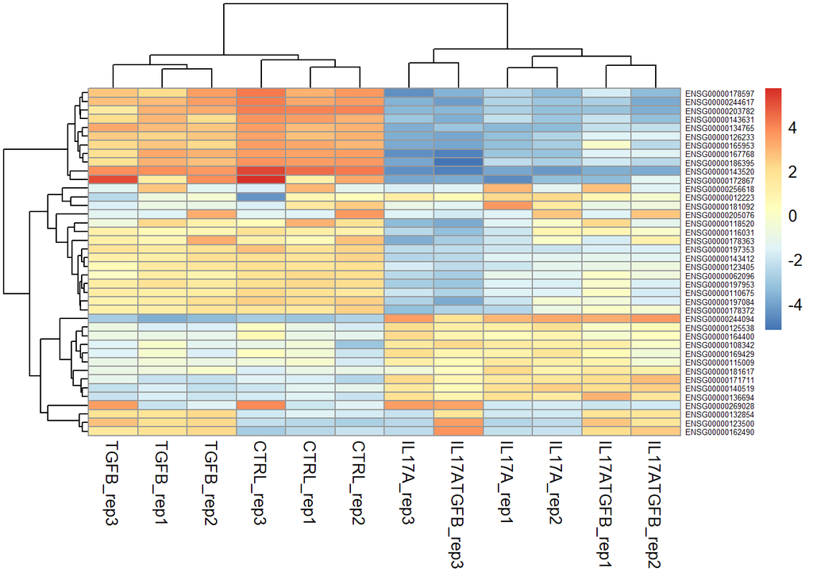

```r
topVarGenes <- head(order(rowVars(assay(vsd)), decreasing = TRUE), 40)
mat  <- assay(vsd)[ topVarGenes, ]
mat1 <- mat[,c(1:6,7:9,13:15)]
mat1  <- mat1 - rowMeans(mat1)
anno <- as.data.frame(colData(vsd)[,c("characteristics_ch1.1","source_name_ch1")])
pheatmap(mat = mat1, fontsize_row = 5)
```

We finish our expression analysis with the volcano plot:

```r
dds<-ddslist$`source_name_ch1`
df2<-as.data.frame(counts(dds))
colData<-colData(dds)
metadata<-metadata(dds)
database<-org.Hs.eg.db

dds <- DESeq(dds, betaPrior=FALSE)
res <- results(dds,
               contrast = c('source_name_ch1','CTRL','IL_17A'))
res <- lfcShrink(dds,
                 contrast = c('source_name_ch1','CTRL','IL_17A'), res=res, type = 'normal')
```

```
## using 'normal' for LFC shrinkage, the Normal prior from Love et al (2014).
##
## Note that type='apeglm' and type='ashr' have shown to have less bias than type='normal'.
## See ?lfcShrink for more details on shrinkage type, and the DESeq2 vignette.
## Reference: https://doi.org/10.1093/bioinformatics/bty895
```

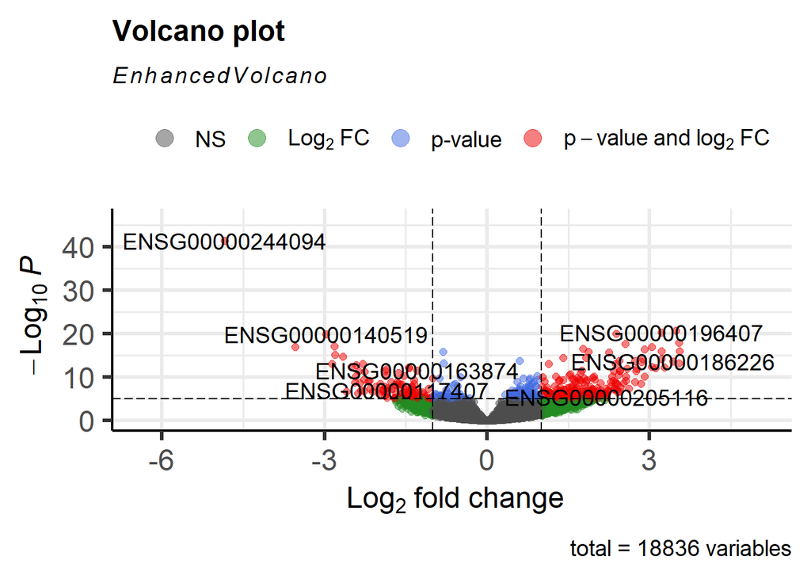

```r
EnhancedVolcano(res,
                lab = rownames(res),
                x = 'log2FoldChange',
                y = 'pvalue')
```

## GO enrichment analysis (ORA)

We perform GO enrichment analysis (Biological Processes) with an ORA approach, utilizing a subset of genes that have a padj < 0.001 and a l2fc > 3.

```r
dds <- DESeq(dds)
```

```
## found already estimated dispersions, replacing these
```

```r
res <- results(dds,contrast = c('source_name_ch1','IL_17A','CTRL'))

res<-res[!is.na(res$padj),]
SigExpGenes<-res[(res$padj < 0.001) & (abs(res$log2FoldChange)>3),]
rownames(SigExpGenes)%>%length #significally expressed genes
```

```
## [1] 100
```

```r
rownames(counts(dds))%>%length #all tested genes
```

```
## [1] 18836
```

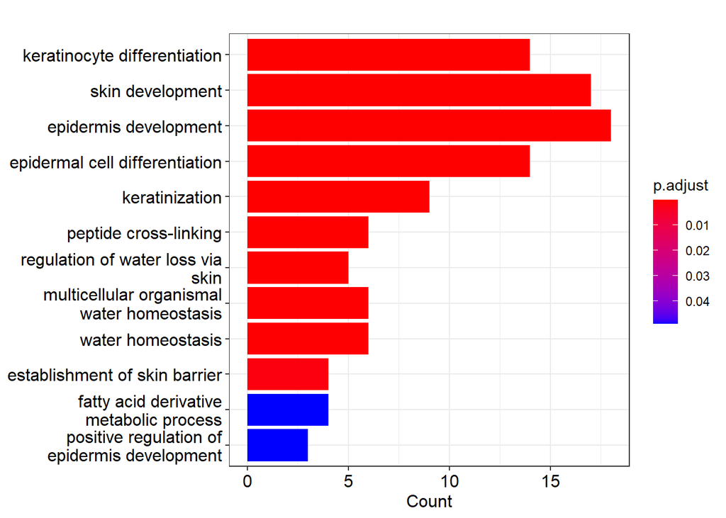

```r
ego <- enrichGO(gene          = rownames(SigExpGenes),
                universe      = rownames(counts(dds)),
                OrgDb         = org.Hs.eg.db,
                keyType       = 'ENSEMBL',
                ont           = "BP",
                pAdjustMethod = "BH",
                pvalueCutoff  = 0.05,
                qvalueCutoff  = 0.05,
                readable      = F)

dfego<-as.data.frame(ego[,-8])

barplot(ego, showCategory = 20)
```

## KEGG enrichment analysis (ORA)

In this part we perform a pathway enrichment analysis using KEGG database. The following code will not be executed, it is included only as a reference to dispaly the methodology used. We performed the analysis based on three comparisons: IL17-A against control, TGF-β against control, and finally, IL17ATGFB against TGF-β. We chose these comparisons to be able to validate some of the results indicated in the paper.

```r
dds <- DESeq(dds)
res <- results(dds,contrast = c('source_name_ch1','IL_17A','CTRL'))
res<-res[!is.na(res$padj),]
SigExpGenes<-res[(res$padj < 0.001) & (abs(res$log2FoldChange)>1),]
rownames(SigExpGenes)%>%length #significally expressed genes
rownames(counts(dds))%>%length #all tested genes including NAs

search_kegg_organism('sapiens', by='scientific_name')

SigExpGenes$ENTREZID<-AnnotationDbi::mapIds(x=database,
                       keys = rownames(SigExpGenes),
                       column = "ENTREZID",
                       keytype = "ENSEMBL",
                       multiVals = "first")

kk <- enrichKEGG(gene         = SigExpGenes$ENTREZID,
                 organism     = 'hsa',
                 pAdjustMethod = "BH",
                 qvalueCutoff = 0.2,
                 pvalueCutoff = 0.05)

kkres<-as.data.frame(kk@result)

significantkkres<-kkres[kkres$pvalue<kk@pvalueCutoff & kkres$p.adjust<kk@pvalueCutoff & kkres$qvalue < kk@qvalueCutoff,2,drop=F]

geneList<-SigExpGenes$log2FoldChange
names(geneList)<-SigExpGenes$ENTREZID

download.pathway<-function(keggid){
folder<-"pics"
if (!("pics" %in% list.files())) {dir.create(folder)}
setwd(folder)
pic <- pathview(gene.data  = geneList,
                     pathway.id = keggid,
                     species    = stringr::str_extract(keggid,"[A-z]+"),
                     limit      = list(gene=max(abs(geneList)), cpd=1))
setwd("..")
}
rownames(significantkkres)
lapply(rownames(significantkkres),download.pathway)
```

We did the above passages for the first two comparisons, and individuated some pathways that were significant for the study. We then downloaded these specific pathways for the third comparison, as shown below (first part with gene selection is similar to above). For this last part we used a padj treshold of 0.05 to highlight better the effect that IL17-A had on the combined treatment.

```r
hsa04512 <- pathview(gene.data  = geneList,
                     pathway.id = "hsa04512",
                     species    = "hsa",
                     limit      = list(gene=max(abs(geneList)), cpd=1))

hsa04310 <- pathview(gene.data  = geneList,
                     pathway.id = "hsa04310",
                     species    = "hsa",
                     limit      = list(gene=max(abs(geneList)), cpd=1))

sa04060 <- pathview(gene.data  = geneList,
                    pathway.id = "hsa04060",
                    species    = "hsa",
                    limit      = list(gene=max(abs(geneList)), cpd=1))
```

First, let’s examine the Cytokine-cytokine receptor interaction, that was shown to be enriched in all three cases.

IL17-A - CRTL:

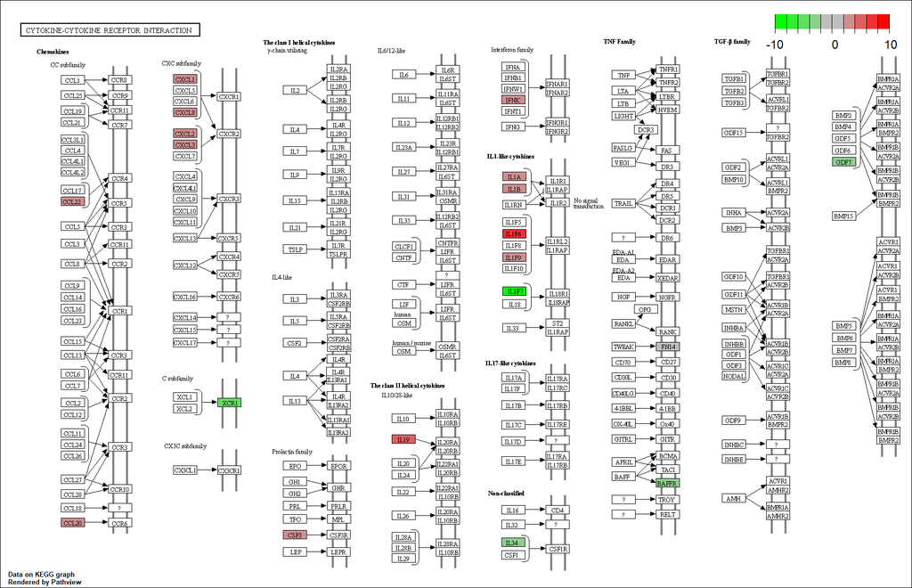

TGF-β - CRTL:

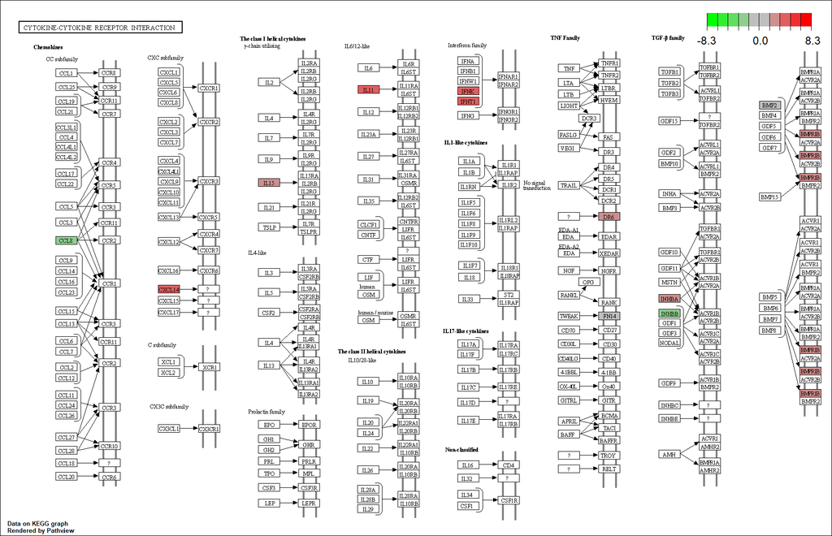

IL17ATGFB - TGF-β:

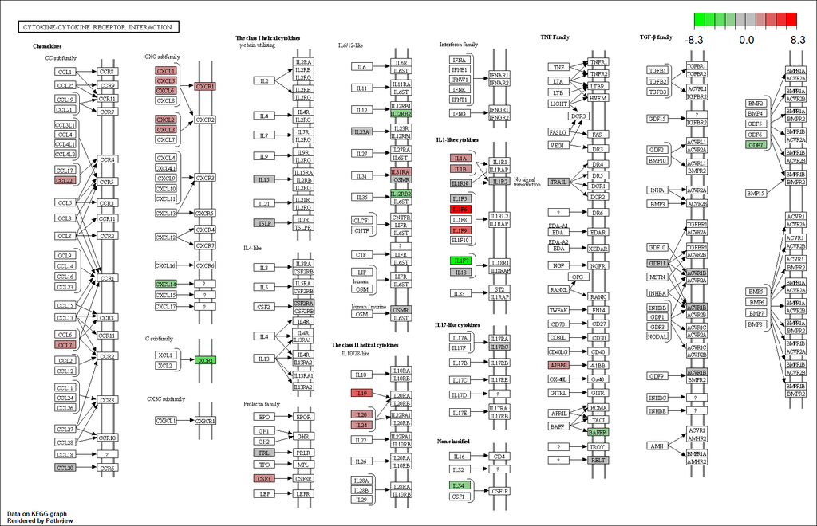

In the original paper it is indicated that an anti-fibrogenic function of IL17-A may be due to the downregulation of the wnt signaling. This effect is relevant even when comparing IL17ATGFB treated cells with TGF-β only.

IL17ATGFB - TGF-β:

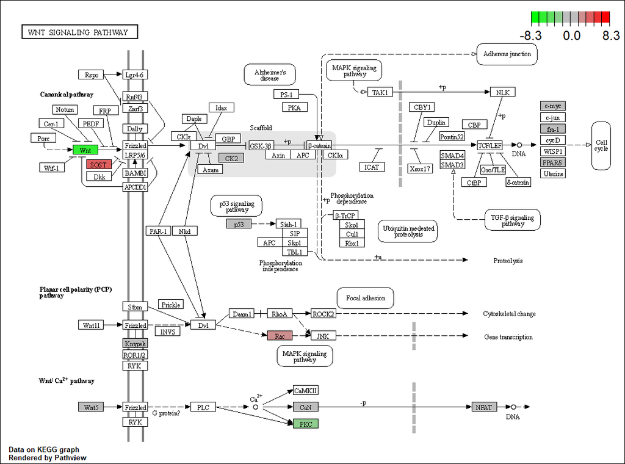

We are also interested in assessing how the expression in the ECM-receptor interaction pathway is impacted by the treatments. As shown below, we can see that IL17-A does not impact the expression of collagen in any meaningful way. TGF does, with a strong upregulation. When comparing IL17ATGFB to TGF-β only, we can see that collagen levels are not impacted, but the level of laminin genes is overexpressed. Laminins support and influence the migration and the function of immune cells, enabling Leukocyte recruitment to sites of injury or inflammation. These observations support the idea expressed in the paper, that IL17 does not directly impact fibrogenesis by reducing collagen expression (even though a slight downregulation is present), but indirectly by impacting other pathways, like the wnt signaling pathway indicated before.

IL17-A - CRTL:

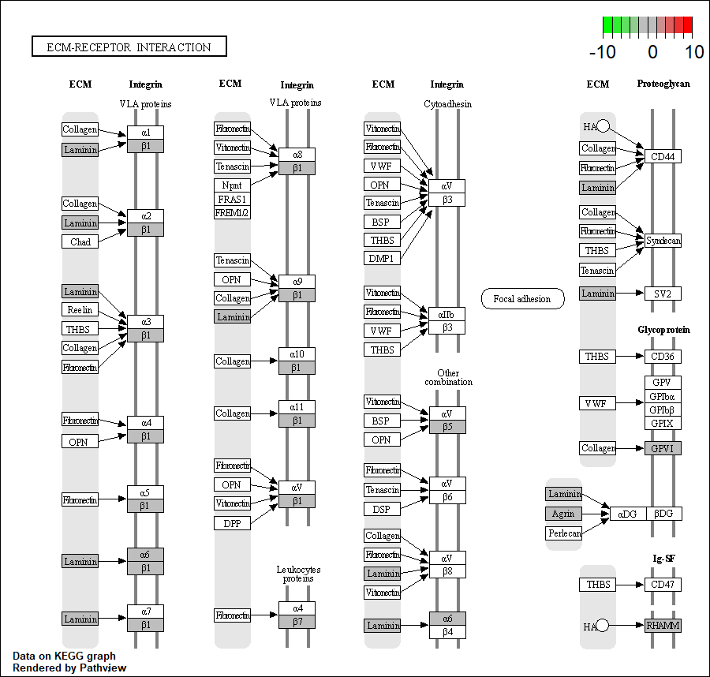

TGF-β - CRTL:

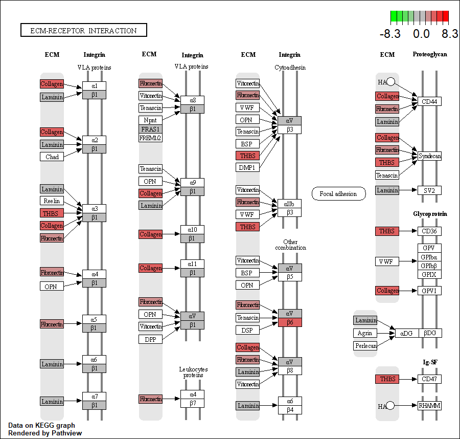

IL17ATGFB - TGF-β:

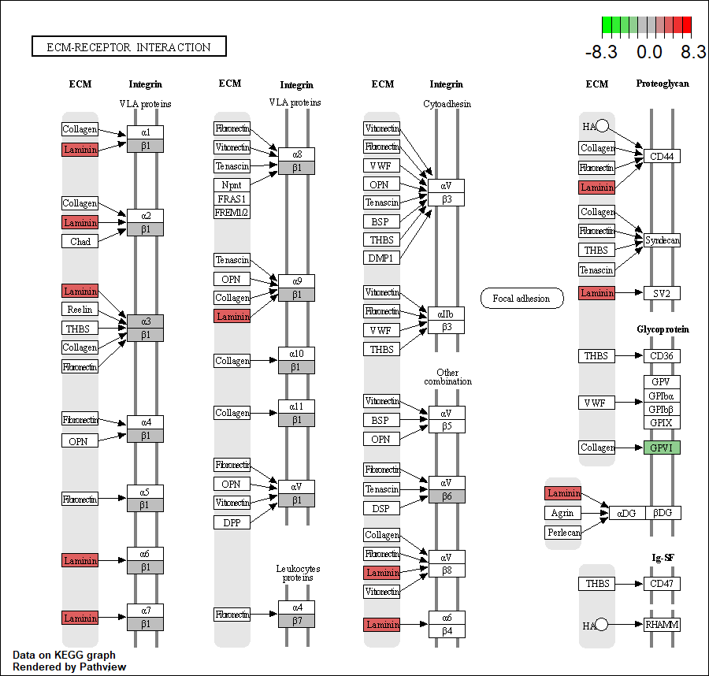

## EdgeR

We prepare the data for the EdgeR Analysis. We use EdgeR to validate our DeSeq2 analysis, and see if there is any substantial difference.

```r
ddslist<-readRDS(file = "dds.rds")
count_data<-as.data.frame(counts(ddslist$source_name_ch1))
groups<-ddslist$source_name_ch1@colData$source_name_ch1
d <- DGEList(counts=count_data, group=groups)
```

Filtering:

```r
cpm <- cpm(d)
keep <- rowSums(cpm>1) >= ncol(cpm)/2
d <- d[keep, ]
d$samples$lib.size <- colSums(d$counts)
```

We then perform normalization:

```r
d <- calcNormFactors(d, method= "TMM")
d$samples$norm.factors
```

```
##  [1] 1.0255929 0.9952077 0.9557149 1.0828586 1.0416541 1.0553752 0.9687746
##  [8] 0.9440975 1.0697872 1.0525750 0.9960891 0.9874580 1.0160854 0.9665392
## [15] 0.9688458 0.9503571 0.9422746 0.9977122
```

Exploratory data analysis. We can see that the plot is similar to the one created in DeSeq.

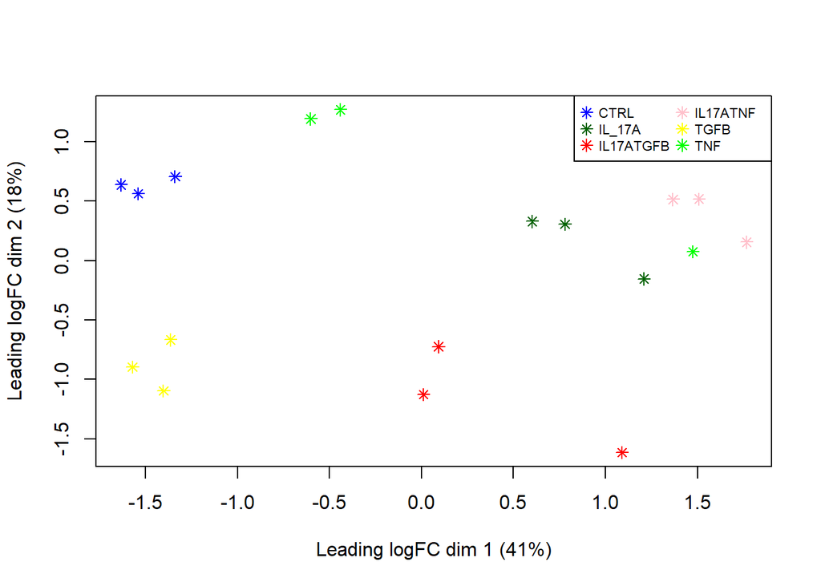

```r
points <- c(0,1,2,15,16,17)
colors <- rep(c("blue", "darkgreen", "red", "pink", "yellow", "green"), 2)
plotMDS(d, col=colors[groups], pch=8)
col=as.numeric(d$samples$group)
legend("topright",
       as.character(unique(d$samples$group)), col=colors, pch=8, ncol = 2, cex=0.7, pt.cex = 1)
```

We estimate the dispersion in our data. We note that, as we expected, the dispersion decreases as the CPM of the gene increases.

```r
d1 <- estimateCommonDisp(d, verbose=T)
```

```
## Disp = 0.05525 , BCV = 0.2351
```

```r
d1 <- estimateTagwiseDisp(d1)
names(d1)
```

```
##  [1] "counts"             "samples"            "common.dispersion"
##  [4] "pseudo.counts"      "pseudo.lib.size"    "AveLogCPM"
##  [7] "prior.df"           "prior.n"            "tagwise.dispersion"
## [10] "span"
```

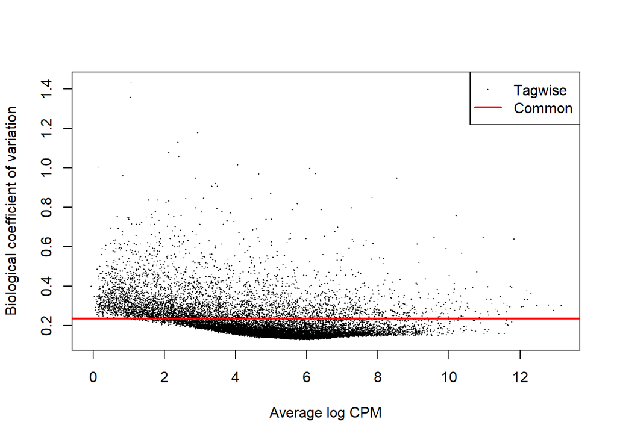

```r
plotBCV(d1)
```

```r
et12 <- exactTest(d1) # , pair=unique(groups)(removed this from brackets)
topTags(et12, n=10)
```

```
## Comparison of groups:  IL_17A-CTRL
##                     logFC   logCPM       PValue          FDR
## ENSG00000244094  6.530655 8.399997 2.196111e-32 3.009112e-28
## ENSG00000196407 -3.826804 3.713591 6.262338e-20 4.290328e-16
## ENSG00000140519  3.571781 8.641668 1.015809e-19 4.639540e-16
## ENSG00000134765 -8.036533 7.019971 2.850506e-19 9.764407e-16
## ENSG00000156282  6.672824 2.784781 1.298239e-18 3.557694e-15
## ENSG00000005001  3.453487 7.635003 1.120230e-17 2.558231e-14
## ENSG00000157368 -2.890159 4.030033 1.951719e-17 3.433133e-14
## ENSG00000104055 -3.527687 4.876371 2.004457e-17 3.433133e-14
## ENSG00000164120 -4.244530 4.898256 2.921300e-16 4.447516e-13
## ENSG00000177494  3.537202 5.072319 3.309169e-16 4.534223e-13
```

```r
de1 <- decideTestsDGE(et12, adjust.method="BH", p.value=0.001)
summary(de1)
```

```
##        IL_17A-CTRL
## Down           247
## NotSig       13330
## Up             125
```

```r
design <- model.matrix(~groups)

y <- estimateDisp(d,design)

# perform quasi-likelihood F-tests:
  fit <- glmQLFit(y,design)
qlf <- glmQLFTest(fit,coef=2)
topTags(qlf)
```

```
## Coefficient:  groupsIL_17A
##                      logFC   logCPM         F       PValue          FDR
## ENSG00000244094  6.5309181 8.399997 109.27357 2.958279e-08 0.0004053434
## ENSG00000010030 -2.6104155 2.580832  87.76714 1.235932e-07 0.0008270601
## ENSG00000095539 -1.8587933 3.814901  77.17579 2.805832e-07 0.0008270601
## ENSG00000196407 -3.8246048 3.713590  76.71918 2.912936e-07 0.0008270601
## ENSG00000109736  0.8385266 7.042648  75.16699 3.313274e-07 0.0008270601
## ENSG00000164402 -2.0002163 6.705392  72.42469 4.183058e-07 0.0008270601
## ENSG00000157368 -2.8892806 4.030031  71.87954 4.385338e-07 0.0008270601
## ENSG00000184500 -1.4511078 4.940594  70.07296 5.139416e-07 0.0008270601
## ENSG00000140519  3.5716945 8.641668  69.45066 5.432449e-07 0.0008270601
## ENSG00000185101 -1.9530203 6.451522  63.44698 9.485167e-07 0.0012513036
```

```r
# perform likelihood ratio tests:
  fit <- glmFit(y,design)
lrt <- glmLRT(fit,coef=2)
topTags(lrt)
```

```
## Coefficient:  groupsIL_17A
##                     logFC   logCPM        LR       PValue          FDR
## ENSG00000244094  6.530627 8.399997 109.50891 1.255391e-25 1.720136e-21
## ENSG00000010030 -2.610801 2.580832  75.58329 3.503135e-18 2.399998e-14
## ENSG00000196407 -3.827289 3.713590  71.55527 2.696000e-17 1.231353e-13
## ENSG00000140519  3.571799 8.641668  67.83766 1.775266e-16 6.081174e-13
## ENSG00000157368 -2.890344 4.030031  66.67506 3.201595e-16 8.773652e-13
## ENSG00000095539 -1.857952 3.814901  65.56306 5.628385e-16 1.285336e-12
## ENSG00000164402 -2.000236 6.705392  64.87583 7.976935e-16 1.561428e-12
## ENSG00000156282  6.674275 2.784782  62.84938 2.231337e-15 3.821722e-12
## ENSG00000134765 -8.036223 7.019971  59.75448 1.074605e-14 1.636026e-11
## ENSG00000005001  3.453487 7.635003  59.27608 1.370321e-14 1.877614e-11
```

Akiyama, Masashi. 2020. “Autoinflammatory Keratinization Diseases (Aikds): Expansion of Disorders to Be Included.” *Frontiers in Immunology* 11: 280.

Froggatt, Heather M, Alfred T Harding, Ryan R Chaparian, and Nicholas S Heaton. 2021. “ETV7 Limits Antiviral Gene Expression and Control of Influenza Viruses.” *Science Signaling* 14 (691): eabe1194.

Huynh, Kieu My, Anny Chuu-Yun Wong, Bo Wu, Marc Horschman, Hongjuan Zhao, and James D Brooks. 2020. “Sprr2f Protects Against Renal Injury by Decreasing the Level of Reactive Oxygen Species in Female Mice.” *American Journal of Physiology-Renal Physiology* 319 (5): F876–84.

Namgaladze, Dmitry, and Bernhard Brüne. 2016. “Macrophage Fatty Acid Oxidation and Its Roles in Macrophage Polarization and Fatty Acid-Induced Inflammation.” *Biochimica Et Biophysica Acta (BBA)-Molecular and Cell Biology of Lipids* 1861 (11): 1796–1807.

Polivka, Laura, Smail Hadj-Rabia, Elodie Bal, Stéphanie Leclerc-Mercier, Marine Madrange, Yamina Hamel, Damien Bonnet, et al. 2018. “Epithelial Barrier Dysfunction in Desmoglein-1 Deficiency.” *Journal of Allergy and Clinical Immunology* 142 (2): 702–6.

Shetty, Shibani, and S Gokul. 2012. “Keratinization and Its Disorders.” *Oman Medical Journal* 27 (5): 348.